# Course Project: Practical Machine Learning

Jawad Rasool

August 25, 2019

## Introduction

Using devices such as Jawbone Up, Nike FuelBand, and Fitbit it is now possible to collect a large amount of data about personal activity relatively inexpensively. These type of devices are part of the quantified self movement - a group of enthusiasts who take measurements about themselves regularly to improve their health, to find patterns in their behavior, or because they are tech geeks. One thing that people regularly do is quantify how much of a particular activity they do, but they rarely quantify how well they do it.

Six participants had accelerometers on the belt, forearm, arm, and dumbell. They were asked to perform barbell lifts correctly and incorrectly in 5 different ways. In this project, the goal is to use data from these accelerometers and predict the manner in which they did the exercise (given in the “classe” variable in the training set). Using the prediction model, 20 different test cases are also predicted.

## Data used in this Project

The data for this project come from [HAR](http://groupware.les.inf.puc-rio.br/har), and a detaled description of their work is provided in “Velloso, E.; Bulling, A.; Gellersen, H.; Ugulino, W.; Fuks, H. **Qualitative Activity Recognition of Weight Lifting Exercises**, *Proceedings of 4th International Conference in Cooperation with SIGCHI (Augmented Human ’13)*, Stuttgart, Germany: ACM SIGCHI, 2013.” According to this paper, six male participants, aged between 20-28 years with little weight lifting experience, were asked to perform one set of 10 repetitions of the Unilateral Dumbbell Biceps Curl in five different fashions:

- exactly according to the specification (Class A),
- throwing the elbows to the front (Class B),
- lifting the dumbbell only halfway (Class C),
- lowering the dumbbell only halfway (Class D) and
- throwing the hips to the front (Class E).

Class A corresponds to the specified execution of the exercise, while the other 4 classes correspond to common mistakes.

### Loading the libraries and the dataset

First, load the libraries that are needed for the project:

```r
library(caret)
library(rattle)
library(rpart)
```

Then download the training data:

```r
# load training data
url_train <- "https://d396qusza40orc.cloudfront.net/predmachlearn/pml-training.csv"
training <- read.csv(url(url_train),header=TRUE)
dim(training)
```

```
## [1] 19622   160
```

```r
table(training$classe)
```

```
##
##    A    B    C    D    E
## 5580 3797 3422 3216 3607
```

We see that there are 19622 observations and 160 variables. The variable *classe* is what the models will try to predict. Finally, I download the test data, on which I’ll use my prediction model to predict 20 different cases:

```r
# load testing data
url_test <- "https://d396qusza40orc.cloudfront.net/predmachlearn/pml-testing.csv"
testing <- read.csv(url(url_test),header=TRUE)
dim(testing)
```

```
## [1]  20 160
```

## Data Preparation

First, I set the seed for reproducibility.

```r
# set the seed for reproducibility
set.seed(1979)
```

I now remove the following variables from the dataset:

- Variabels that are for identification purposes only
- Variables with more than 80% of missing values
- Near zero variance variables

```r
# remove first 5 columns since they are for identification
myTraining <- training[, -(1:5)]

# remove columns with many missing values
missing    <- sapply(myTraining, function(x) mean(is.na(x))) > 0.8
myTraining <- myTraining[, missing==FALSE]

# remove variables with Nearly Zero Variance
nZV <- nearZeroVar(myTraining)
myTraining <- myTraining[, -nZV]

dim(myTraining)
```

```
## [1] 19622    54
```

We are now left with 54 variables in our dataset. This number is still very high and use of PCA to reduce the number of variabels might not be a bad idea. However, I’ll not use it in this project.

Now, I split the training dataset into training (70%) and validation set (30%). I’ll use validation set for testing the performance of my models and selecting the best model.

```r
# data partition
inTrain <- createDataPartition(myTraining$classe, p=0.7, list=FALSE)
myValidation <- myTraining[-inTrain, ]
myTraining <- myTraining[inTrain, ]
dim(myTraining); dim(myValidation)
```

```
## [1] 13737    54
```

```
## [1] 5885   54
```

## Modeling

We use three different models to predict the outcome. These models are decision tree, random forest and gradient boosting machine.

#### Decision Tree

We first create the model, and then plot the classification tree as a dendogram.

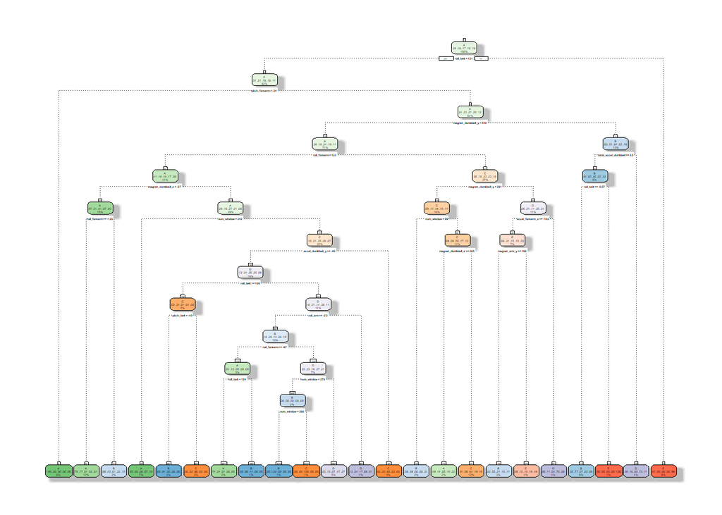

```r
# Decision Tree
model_dt <- rpart(classe ~ ., data=myTraining, method="class")
fancyRpartPlot(model_dt, sub="")
```

We now check the performance of the model on the validation dataset:

```r
# Prediction on validation set
prediction_dt <- predict(model_dt, newdata=myValidation, type = "class")
# Confusion Matrix
cm_dt <- confusionMatrix(myValidation$classe, prediction_dt)
```

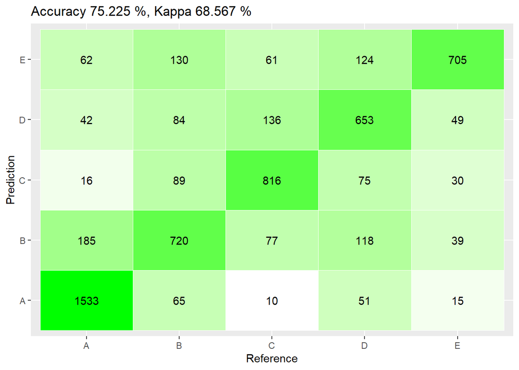

We see that the accuracy is around 75%, which is not very high. The **out-of-sample error** is 25%.

#### Random Forest

We now fit the random forest model, and use **3-fold cross-validation** to select optimal tuning parameters for the model:

```r
# Control Parameters
trc <- trainControl(method="cv", number=3, verboseIter=FALSE)
# Random Forest
model_rf <- train(classe ~ ., data=myTraining, method="rf", trControl=trc)
```

We now check the performance of the model on the validation dataset:

```r
# Prediction on validation set
prediction_rf <- predict(model_rf, newdata=myValidation)
# Confusion matrix
cm_rf <- confusionMatrix(myValidation$classe, prediction_rf)
```

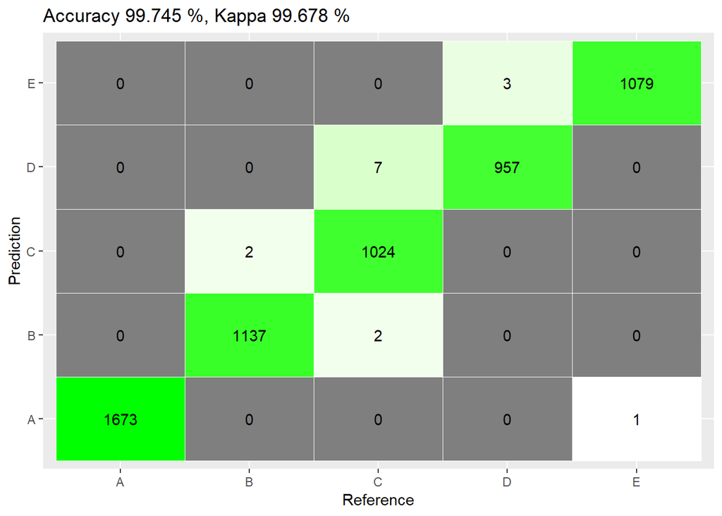

With random forest, we reach an accuracy of 99.7% using cross-validation with 3 steps. The **out-of-sample error** is thus 0.3% only. The performance of random forest is excellent, it seems.

#### Gradient Boosting Machine

Finally, we train gradient boosting machine model. We again use **3-fold cross-validation**:

```r
# GBM
model_gbm <- train(classe ~ ., data=myTraining, method="gbm", trControl=trc, verbose=FALSE)
```

We now check the performance of the model on the validation dataset:

```r
# Prediction on validation set
prediction_gbm <- predict(model_gbm, newdata=myValidation)
# Confusion Matrix
cm_gbm <- confusionMatrix(myValidation$classe, prediction_gbm)
```

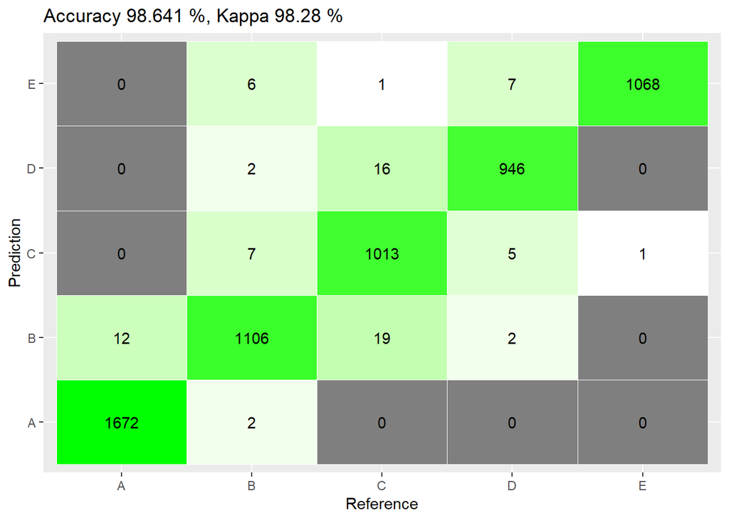

With gradient boosting, we achieve an accuracy of 98.6% on the validation dataset. The **out-of-sample error** is thus 1.4% only. The gradient boosting model performed very close to the random forest model.

## Prediction on Test Data

As we have seen in the last section, performance of the random forest model is the best among the three models. I’ll, therefore, use it to predict the values of *classe* variable for the test data containing 20 observations:

```
##  [1] B A B A A E D B A A B C B A E E A B B B
## Levels: A B C D E
```